# IODS course project

```r
# Boston_scale is changed to data frame format
boston_scaled<-as.data.frame(boston_scaled)

# create a categorical variable of the crime rate
# Creat scaled_crim
scaled_crim<-boston_scaled$crim

# create a quantile vector of crim
bins<-quantile(scaled_crim)

# create the categorical variable ´crime´
crime<-cut(scaled_crim, breaks=bins, include.lowest=TRUE, label=c("low", "med_low", "med_high", "high"))

# remove the original crim from the dataset
boston_scaled<-dplyr::select(boston_scaled, -crim)

# add the new categorical value to scaled data
boston_scaled<-data.frame(boston_scaled, crime)

# splitting the Boston data set to test and train sets
# number of rows in data set
n<-nrow(boston_scaled)

# choose randomly 80% of the rows
ind<-sample(n, size=n*0.8)

# create train and test sets
train<-boston_scaled[ind,]
test<-boston_scaled[-ind,]
```

The linear discriminant analysis is then fit to the train set. The categorical crime rate is the target variable and all the other variables in the dataset are predictor variables.

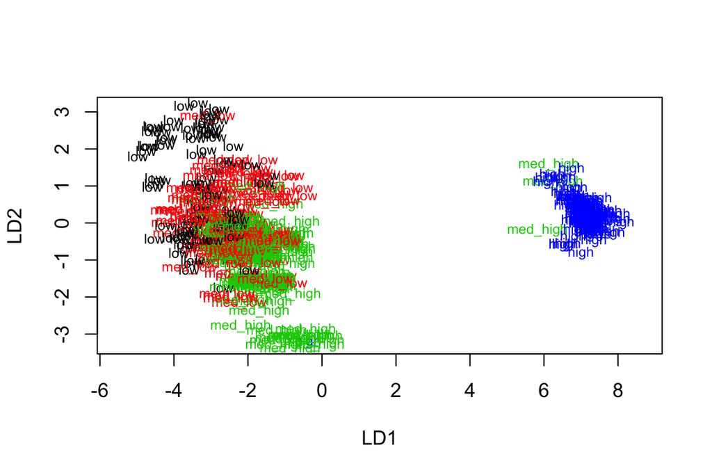

```r
# LDA on the train set, categorical crime rate as target variable, all other variables as predictor variables.
lda.fit<-lda(crime~., data=train)

# target class as numeric
classes<-as.numeric(train$crime)

# draw the LDA (bi)plot, arrows added
plot(lda.fit, dimen=2, col=classes, pch=classes)
```

Next the crime categories are saved to test data and then the categorical crime variable is removed from the test dataset. After this prediction of the classes is made with LDA model and results are cross tabulated with the crime categories from the test set. From the cross tabulation, the prediction of teh model (prediction as probabilities), it seems that high prediction is the most accurate one and next is the low. Then the medium ones are not that well predicted.

```r
# save the crime categories from the test data
correct_classes<-test$crime

# remove the categorical crime from test data
test<-dplyr::select(test, -crime)

# precict classes with test data
lda.pred<-predict(lda.fit, newdata=test)

# cross tabulate the results
table(correct=correct_classes, predicted=lda.pred$class)
```

```
##           predicted
## correct    low med_low med_high high
##   low       15       8        2    0
##   med_low    7      12        4    0
##   med_high   0      10       16    3
##   high       0       0        0   25
```

Lastly, the distances between the observations are calculated and k-means algorith is run on the dataset.

[figure not shown]

```r
# reload Boston data set
data(Boston)

# center and standardize variables
boston_scaled<-scale(Boston)

# calculate the distances between observations
dist_eu<-dist(Boston)

# k-means clustering
km<-kmeans(dist_eu, centers=15)

# plot the dataset with clusters
pairs(Boston, col=km$cluster)
```

Based on the plot, the optimal number of clusters is 2, because then the total WCSS drops radically in the figure and the algorithm is rerun with this. The clusters are then visualized with a plot where clusters are separated with colors and results then interpreted.

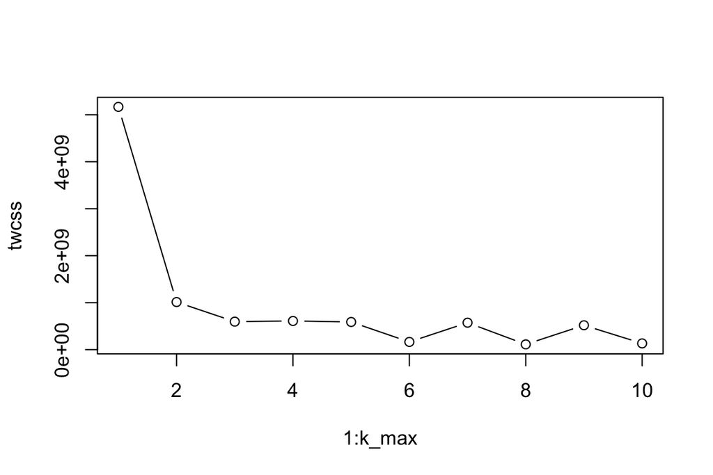

```r
# set.seed to prevent producing different results everytime
set.seed(123)

# calculate the distances between observations
dist_eu<-dist(Boston)

# determine the number of clusters
k_max<-10

# calculate the total WCSS
twcss<-sapply(1:k_max, function(k){kmeans(dist_eu, k)$tot.withinss})

# visualize the results
plot(1:k_max, twcss, type='b')
```

[figure not shown]

```r
# k-means clustering
km<-kmeans(dist_eu, centers=2)

# plot the dataset with clusters
pairs(Boston, col=km$cluster)
```

# Week 5

This week we have used the data from United Nations Development Programme, Human Development Reports ([hdr.undp.org](http://hdr.undp.org/en/content/human-development-index-hdi)).

From the reports, the two datasets of Human Development Index (HDI) and Gender Inequality Index were downloaded, combined, and some data variables were selected for this week’s analysis exercise.

```r
# Load the human.txt data into R.

human<-read.table("~/Desktop/IODS-project/data/human.txt", sep="", header=T)

# Explore the structure and the dimensions of the data
str(human)
```

```
## 'data.frame':    155 obs. of  8 variables:
##  $ Edu2.FM  : num  1.007 0.997 0.983 0.989 0.969 ...
##  $ Labo.FM  : num  0.891 0.819 0.825 0.884 0.829 ...
##  $ Edu.Exp  : num  17.5 20.2 15.8 18.7 17.9 16.5 18.6 16.5 15.9 19.2 ...
##  $ Life.Exp : num  81.6 82.4 83 80.2 81.6 80.9 80.9 79.1 82 81.8 ...
##  $ GNI      : int  64992 42261 56431 44025 45435 43919 39568 52947 42155 32689 ...
##  $ Mat.Mor  : int  4 6 6 5 6 7 9 28 11 8 ...
##  $ Ado.Birth: num  7.8 12.1 1.9 5.1 6.2 3.8 8.2 31 14.5 25.3 ...
##  $ Parli.F  : num  39.6 30.5 28.5 38 36.9 36.9 19.9 19.4 28.2 31.4 ...
```

```r
dim(human)
```

```
## [1] 155   8
```

In our dataset we have 155 objects and 8 variables, so we have 155 rows (different countries) and 8 columns. All the variables are recogniced as numerical, most of them have decimal values, but the GNI and Mat.Mor are integers. The chosen 8 variables (column heading abbreviations) from larger data set describe following things:

1. The proportion of females divided with proportion of males with at least secondary education (Edu2.FM).
2. The proportion of females divided with the proportion of males in the labour force. (Labo.FM)
3. Expected years of schooling for children of school entering age (Edu.Exp)
4. Life expectancy at birth (Life.Exp)
5. Gross national income per capita (GNI)
6. Maternal mortality ratio (Mat.Mor)
7. Adolescent birth rate (Ado.Birth)
8. Percetange of female representatives in parliament (Parli.F)

```r
# Show a graphical overview of the data
# Access to ggplot2 and tidyr
library(ggplot2)
library(tidyr)

# Gathering columns into key-value pairs and drawing a bar plot of each variable
human_g<-gather(human)
glimpse(human_g)
```

```
## Observations: 1,240
## Variables: 2
## $ key   <chr> "Edu2.FM", "Edu2.FM", "Edu2.FM", "Edu2.FM", "Edu2.FM", "...
## $ value <dbl> 1.0072389, 0.9968288, 0.9834369, 0.9886128, 0.9690608, 0...
```

[figure not shown]

```r
ggplot(human_g, aes(value)) +facet_wrap("key", scales="free")+geom_bar()
```